# QMM1002 Case Study 2 [20%]

Agbadu Goodnews

A00238219

Due: April 21, 2022 at 11:59PM

## **Introduction**

For this case study, personal data was about how I spent my day as an international student in Canada, In order to collect these data, I used a personalized data sheet to record my daily activities for two terms. The data was collected from September 10th, 2021 to April 14th, 2022. I assigned a total of ten (10) variables shown in the table below.

| Variable | Type |
| --- | --- |
| Date | Identifier |
| Hours in Class | Quantitative |
| Hours Studying | Quantitative |
| Hours Sleeping | Quantitative |
| Number of Times Leaving the House | Quantitative |
| Watching the News | Categorical |
| Games | Categorical |
| Stress Level (1 - 5) | Categorical |
| Calls | Quantitative |
| Semester (F21 or W22) | Categorical |

In this final report, I will also be working with the personalized data collected by current and past students in QMM1002 intermittently between September 10, 2019 and February 21, 2022. The variables collected for all students are shown in the table below.

| Variable | Type |
| --- | --- |
| Date | Identifier |
| Hours Studying | Quantitative |
| Term (F19, W20, F21 or W22) | Categorical |
| Program (BAPG, CAGC, HAGC) | Categorical |

**Summary Statistics**

These summary statistics can be used to compare between the amount of time I spend studying and other students by program.

| Data Set | Mean | Standard Deviation |
| --- | --- | --- |
| Goodnews | 4.712973 | 2.1924882 |
| All Students | 3.6007841 | 2.3552081 |
| BAPG | 3.5428587 | 2.3661103 |
| CAGC | 4.079602 | 2.545816 |
| HAGC | 3.8118149 | 2.1271117 |

At the end of this report, I will use my personalized data set and a combined class data set to answer the questions such as; Are there differences in the average study times for students in the different analytics streams?, Is the distribution of days studied more than 3.13 hours (the average daily study time for students at McGill) the same for students in the different analytics streams (or in other words, independent of program stream)? and How does my personal study time change over time?. To answer these questions, I will employ the ANOVA,chi-square tests and Time-series statistical analysis methods.

## **Data Analysis**

### Part 1: ANOVA

In this section of the analysis, I will begin by testing the hypothesis that the mean number of hours studied is the same for all three programs at 0.05 level of significance.

The test for hypothesis ($H_0: \mu_{BAPG} = \mu_{CAGC} = \mu_{HAGC}$, $H_A:$ At least one mean is different) using 50 random selected days. Performing the test returned a p-value of 0.765 > $\alpha = 0.05$.So we do not reject the null and conclude that the number of hours studied in the three programs are not significantly different.

For testing the hypothesis that the mean number of hours studied is the same for all three programs, some assumptions/conditions is required.

#### 1.Independence Assumption

The independence assumptions are met because 50 days were randomly selected with independence between groups i.e BAPG,CAGC and HAGC.

#### 2.Similar Variance Assumption

Similar variance assumption is met because it shows no major skews, no systematic changes in variation

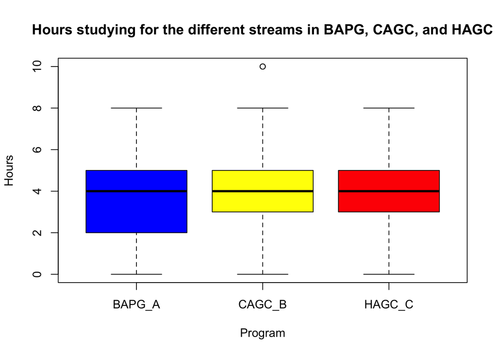

#### 3.Normal Population Assumption

Normal population assumption shows a fairly normal histogram due to the size of the data.

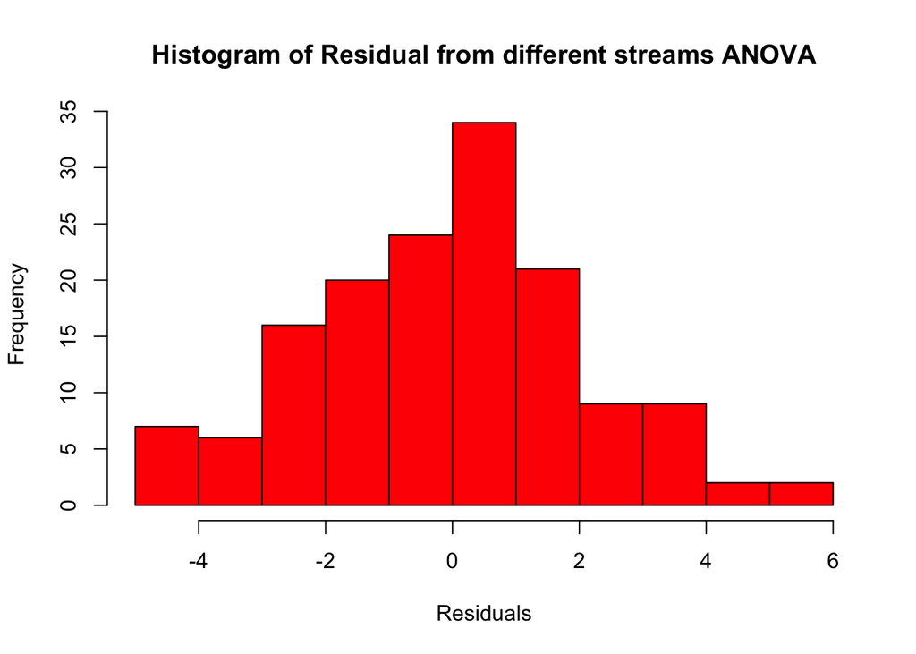

The conditions required for using ANOVA supports the accuracy of the findings because all conditions are met.

```
##   Tukey multiple comparisons of means
##     95% family-wise confidence level
##
## Fit: aov(formula = Score ~ Program, data = programs)
##
## $Program
##                       diff        lwr      upr     p adj
## CAGC_B-BAPG_A 2.710000e-01 -0.7403431 1.282343 0.8013962
## HAGC_C-BAPG_A 2.710000e-01 -0.7403431 1.282343 0.8013962
## HAGC_C-CAGC_B 1.776357e-15 -1.0113431 1.011343 1.0000000
```

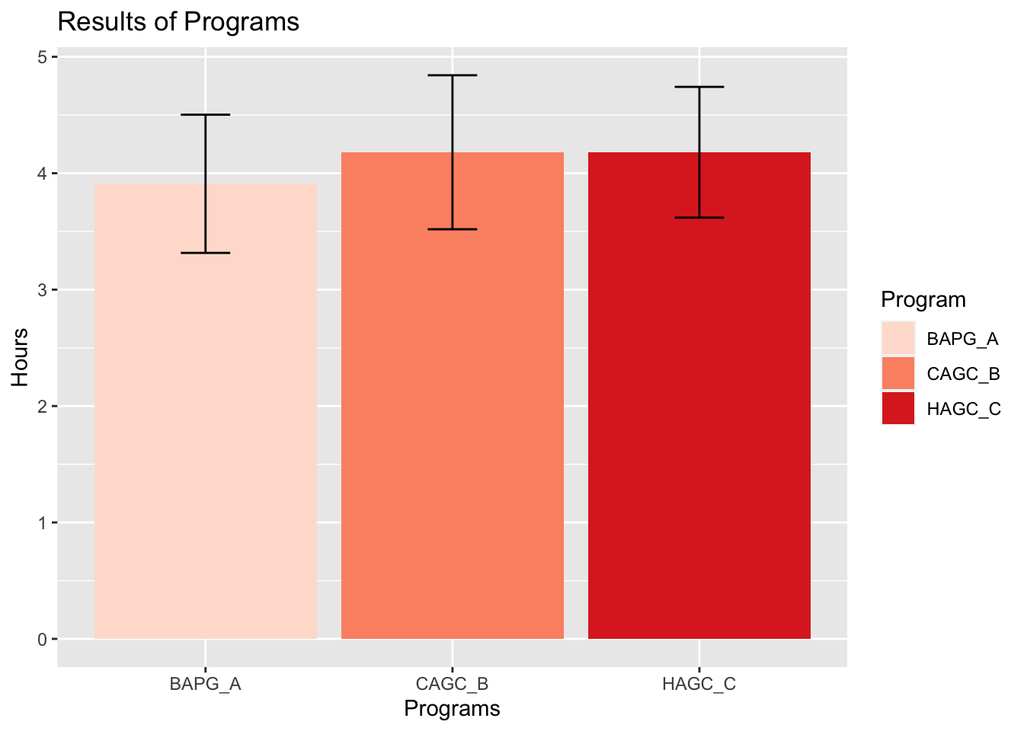

Determining which mean(s) is/are different using Tukey’s HSD test shows that there is no significant evidence that the pair of means (CAGC to BAPG,HAGC to BAPG and HAGC to CAGC) are different. This also support the test for hypothesis that we do not reject the null and conclude that the number of hours studied in the three programs are not significantly different. Furthermore, the bar plot of group means above supports the ANOVA and Tukey’s HSD test that Hours in each program are not significantly different. In relation to my daily activities, this findings are not surprising because the three program are related in terms of the course load such as statistics, programming in python and Analytics projects, which requires almost the same amount of time to complete, though business analytics program seems to be more challenging due to the introduction of connected data.

### Part 2: Chi-Square Tests

The test for hypothesis ($H_0:$ The distribution of above and below days is independent of program, $H_A:$ The distribution of above and below days is dependent of program) using 150 random selected days for students. Performing the test using Pearson’s Chi-squared test returned a p-value of 0.8898 > $\alpha = 0.05$. So we do not reject the null and conclude that there is no significant difference in the program distribution for BAPG, CAGC and HAGC.This findings are surprising because when compared to students at McGill that study 3.13 hours on the average. This result supports the notion that Analytices program requires a lot of time and concentration to be successful due to the fact that most of the courses are technical and skill oriented.

```
##
##  Pearson's Chi-squared test
##
## data:  observed.hours
## X-squared = 0.23342, df = 2, p-value = 0.8898
```

#### Assumptions and Conditions

The counted data condition means that the data must be counts for the categories of a categorical variable. For this case study, the number of hours for studying is in counts thereby condition is met.For independence assumption, we think about how the data was collected and weather the counts in the cells are independent of each other. in this case study, the data was collected independently for each semester.In randomization condition 150 random selected days for students shows that it is a random sample of the population while expected cell frequency for above and below is greater than 5 which implies that condition is met. Overall these assumptions and conditions supports the results in the chi-square tests that we do not reject the null and conclude that there is no significant difference in the program distribution for BAPG, CAGC and HAGC.

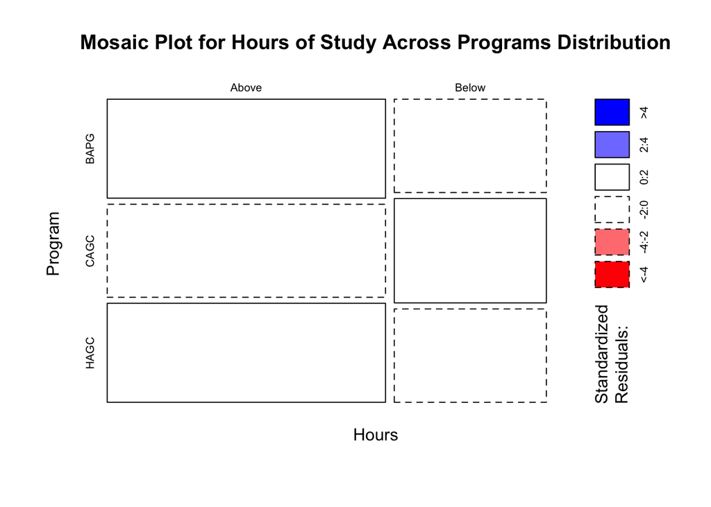

The mosaic plot shows that studying time below 3.13 boxes are the most narrow, because I had the least number of hours studying per program while studying time above 3.13 boxes are the most wide, because I had the most number of hours studying per program. Also no boxes are colored which means all residuals are between -2 and 2. No unusual values and studying time below 3.13 highest bar is CAGC which means below had the most Number of hours studying across program. Furthermore, studying time above 3.13 lowest bar is CAGC which means above had the least of Number of hours studying per program.

### Part 3: Time Series Analysis

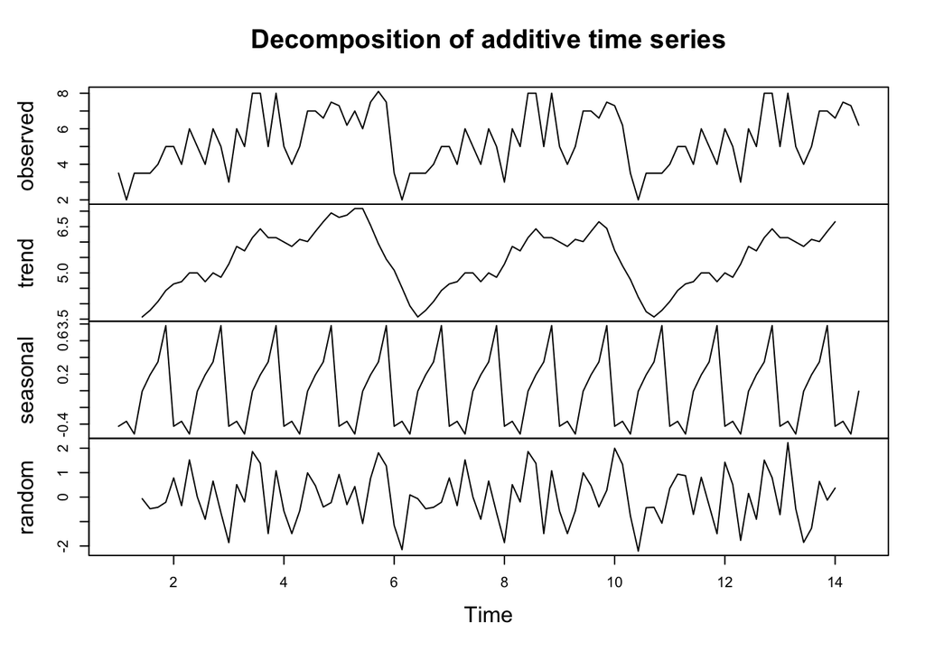

In this time series analysis section of the case study, I will start by explaining the components of the decomposition plot above. Trend/cyclical component shows an upward increasing and downward trend with intervals. Seasonal variation shows a strong seasonal component, general upward and downward pattern each day while irregular/random shows some big irregularities.

Relating to my daily activities, seasonal variation by week maybe as a result of how I plan my homework. For example, some week within the semester especially during the mid-terms, I do more homework compared to other weeks within the semester.

Secondly, the trend shows that I have an up and down trend which maybe as a result of the periods within the semesters that I had to study more. This result was not surprising because in the winter semester, most of the courses had exams which required theoretical knowledge of the course to pass.

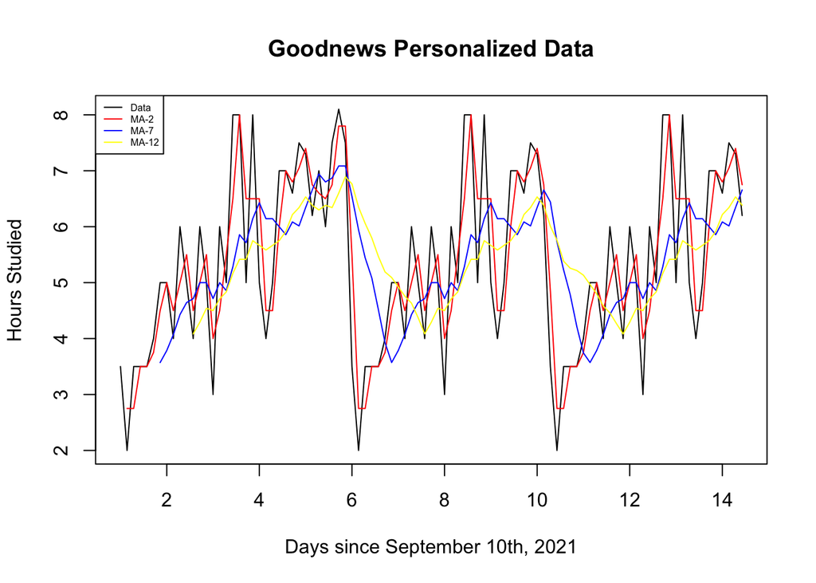

The plot above shows the moving average model for hours studied. Here I am making a plot that allows us to compare each of these moving averages to the original data.The rules for moving averages are that the shorter or the smaller value you pick for the length is going to react to changes faster.MA-2 won’t take very long to see the dip in the data correspond to a difference in the original moving average data. While Ma-7 and MA-12 takes a lot longer to adjust to the dip. Because my hours of time spent studying shows volatility, I want the data to smooth quickly. The volatility shown in my plot was as a result of some days I took off to connect with friends and breaks within the semester which I spent most of the time traveling to Toronto and Vancouver.

```
##           MA-2      MA-7     MA-12
## MSE   2.481505  2.793882  2.857373
## MAD   1.261290  1.354221  1.371285
## MAPE 27.178790 29.463707 29.547825
```

The error forecast above MA-2 has the lowest MSE and MAD when compared to MA-7 and MA-12. Also, MA-2 shows an MAPE of 27% error between the model and the real data values which we can say that the red line in the plot does the best and that is because shorter moving average captures the dips and peaks in the data.

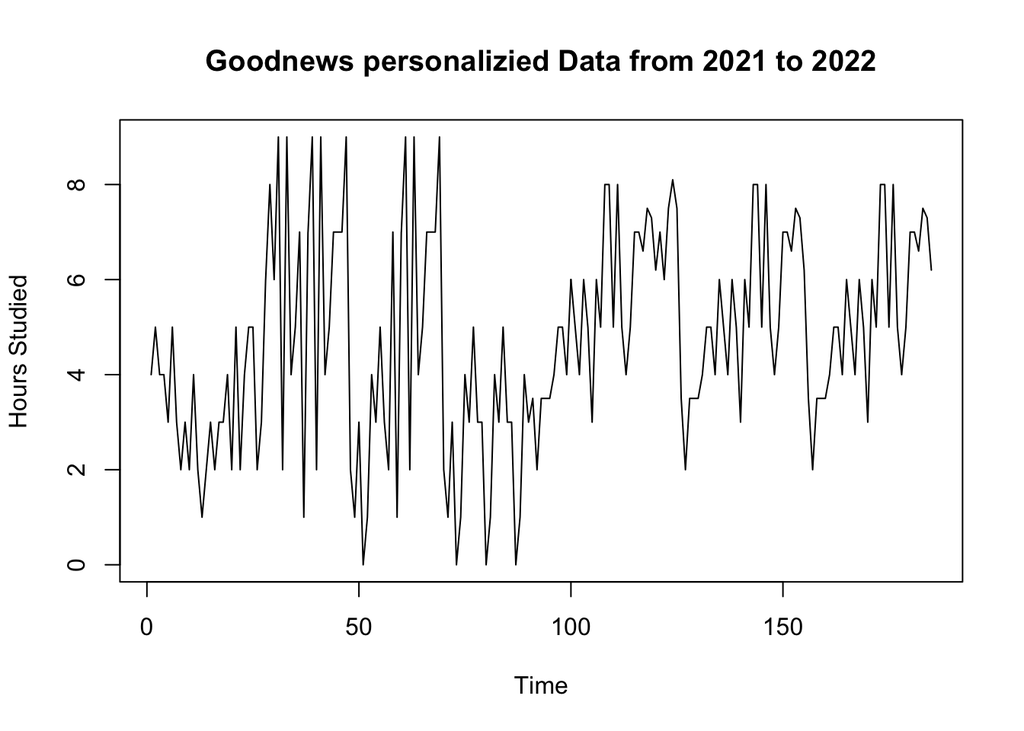

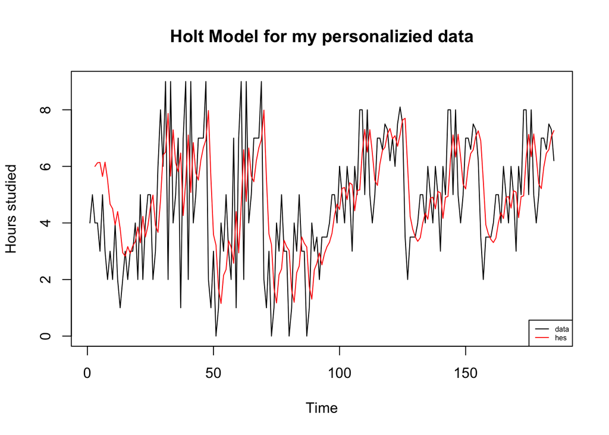

The plot above is taking the predictive values from the Holt exponential smoothing model and comparing them to the real time series data, so the real time series data is in the black while the exponential predictions are in the red. This model was chosen because the decomposition plot shows an upward and downward trend.

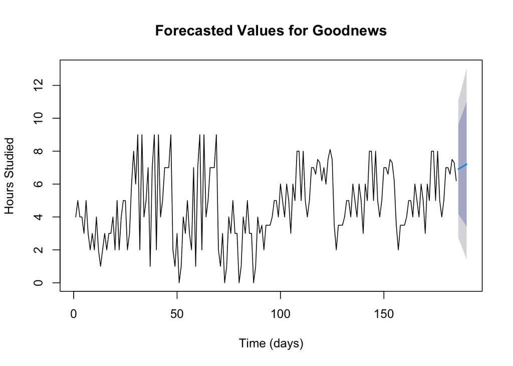

For the future, with 80% confidence intervals inside that darker blue Ben and 95% confidence intervals within that Gray Ben.

## **Conclusion**

To conclude this case study, it is important to reflect on the key findings;

Determining if there are differences in the average study times for students in the different analytics streams, using Tukey’s HSD test shows that there is no significant evidence that the pair of means (CAGC to BAPG,HAGC to BAPG and HAGC to CAGC) are different. This also support the test for hypothesis that we do not reject the null and conclude that the number of hours studied in the three programs are not significantly different.

Answering the questions if the distribution of days studied more than 3.13 hours (the average daily study time for students at McGill) the same for students in the different analytics streams, using Pearson’s Chi-squared test shows that there is no significant difference in the program distribution for BAPG, CAGC and HAGC.

By completing this report, I have learned about my daily habit such as increased study time with a balanced social life. I have decided to implement the following to sustain an effective study-life balance.

1. Join an NGO during the holiday for improved networking and service to humanity.
2. Registering at the gym
3. Coordinate my free time with friends